# Bond Analytics: Price, Yield, Duration & Convexity

### Baby Blue Edition

This notebook implements the core fixed income algorithms for a standard fixed coupon bond quant model:

- **Price from yield** and **yield from price (YTM)** via Newton Raphson with bisection fallback
- **Cash flow schedule** with discount factors and present values
- **Macaulay duration, modified duration, and convexity**
- **Price yield curve** and a **duration vs. duration+convexity** approximation check

```python
#Loading imports
import numpy as np
import pandas as pd
import matplotlib.pyplot as plt
import matplotlib as mpl

#Baby blue theme for the Girlies-------------------------------------------------------------------------------------------------------------
BLUE_DEEP = '#1f6fa3'
BLUE_MID  = '#3fa3d6'
BLUE_BRT  = '#7ec8f0'
BLUE_SOFT = '#cdeefc'
BLUE_PALE = '#eef8fd'
INK       = '#0f3552'

mpl.rcParams['figure.facecolor']  = BLUE_PALE
mpl.rcParams['axes.facecolor']    = '#fbfdff'
mpl.rcParams['axes.edgecolor']    = BLUE_SOFT
mpl.rcParams['axes.labelcolor']   = INK
mpl.rcParams['xtick.color']       = INK
mpl.rcParams['ytick.color']       = INK
mpl.rcParams['text.color']        = INK
mpl.rcParams['axes.titlecolor']   = BLUE_DEEP
mpl.rcParams['grid.color']        = BLUE_SOFT
mpl.rcParams['font.size']         = 11
```

## 1. Bond Terms

```python
#Setting Bond Terms
FACE_VALUE   = 1000.0
COUPON_RATE  = 5.0     # annual %, e.g. 5.0 = 5%
YEARS        = 10.0
FREQ         = 2       #coupon payments per year (1 = annual, 2 = semi annual, 4 = quarterly, 12 = monthly)

print(f"Face value: ${FACE_VALUE:,.2f}")
print(f"Coupon rate: {COUPON_RATE:.2f}% annual, paid {FREQ}x/year")
print(f"Maturity: {YEARS} years")
```

```
Face value: $1,000.00
Coupon rate: 5.00% annual, paid 2x/year
Maturity: 10.0 years
```

## 2. Core Bond Math

```python
#Core Bond Math

def build_cash_flows(face, coupon_rate, years, freq):
    n = round(years * freq)
    c = (coupon_rate/100) * face / freq
    periods = np.arange(1, n+1)
    coupons = np.full(n, c)
    principal = np.zeros(n)
    principal[-1] = face
    times = periods / freq
    return pd.DataFrame({'period': periods, 'time': times, 'coupon': coupons, 'principal': principal})

def price_from_yield(flows, ytm_annual, freq):
    r = ytm_annual/100/freq
    cf = flows['coupon'] + flows['principal']
    df = (1+r) ** (-flows['period'])
    return float((cf*df).sum())

def ytm_from_price(flows, target_price, freq, guess=5.0):
    lo, hi = 1e-4, 100.0
    def f(y): return price_from_yield(flows, y, freq) - target_price
    if f(lo)*f(hi) > 0:
        return None
    y = guess
    for _ in range(60):
        fy = f(y)
        if abs(fy) < 1e-7:
            return y
        h = 1e-4
        dfy = (f(y+h) - f(y-h)) / (2*h)
        y_next = y - fy/dfy if dfy != 0 else (lo+hi)/2
        if not np.isfinite(y_next) or y_next <= 0 or y_next > 100:
            mid = (lo+hi)/2
            if f(lo)*f(mid) <= 0:
                hi = mid
            else:
                lo = mid
            y_next = (lo+hi)/2
        else:
            if fy > 0:
                lo = y
            else:
                hi = y
        y = y_next
    return y

def macaulay_duration(flows, ytm_annual, freq, price):
    r = ytm_annual/100/freq
    cf = flows['coupon'] + flows['principal']
    df = (1+r) ** (-flows['period'])
    weighted_t = (flows['time']*cf*df).sum()
    return weighted_t/price

def modified_duration(mac_d, ytm_annual, freq):
    r = ytm_annual/100/freq
    return mac_d/(1+r)

def convexity(flows, ytm_annual, freq, price):
    r = ytm_annual/100/freq
    cf = flows['coupon'] + flows['principal']
    df = (1+r) ** (-flows['period'])
    s = (cf*df*flows['period']*(flows['period']+1)).sum()
    convex_periods = s/(price*(1+r)**2)
    return convex_periods/(freq**2)

flows = build_cash_flows(FACE_VALUE, COUPON_RATE, YEARS, FREQ)
flows.head()
```

|  | period | time | coupon | principal |
| --- | --- | --- | --- | --- |
| 0 | 1 | 0.5 | 25.0 | 0.0 |
| 1 | 2 | 1.0 | 25.0 | 0.0 |
| 2 | 3 | 1.5 | 25.0 | 0.0 |
| 3 | 4 | 2.0 | 25.0 | 0.0 |
| 4 | 5 | 2.5 | 25.0 | 0.0 |

## 3. Price the Bond at a Given Market Yield

```python
# Price the bond at a given market yield

MARKET_YIELD = 6.0  # annual %, change this to reprice

price = price_from_yield(flows, MARKET_YIELD, FREQ)
mac_d = macaulay_duration(flows, MARKET_YIELD, FREQ, price)
mod_d = modified_duration(mac_d, MARKET_YIELD, FREQ)
conv  = convexity(flows, MARKET_YIELD, FREQ, price)

status = 'Par' if abs(price-FACE_VALUE) < 0.5 else ('Premium' if price > FACE_VALUE else 'Discount')

print(f"Market yield:        {MARKET_YIELD:.3f}%")
print(f"Clean price:         ${price:,.2f}  ({status})")
print(f"Macaulay duration:   {mac_d:.3f} years")
print(f"Modified duration:   {mod_d:.3f}")
print(f"Convexity:           {conv:.3f}")
```

```
Market yield:        6.000%
Clean price:         $925.61  (Discount)
Macaulay duration:   7.895 years
Modified duration:   7.665
Convexity:           71.785
```

## 4. Solve for Yield-to-Maturity Given a Market Price

```python
MARKET_PRICE = 925.0  # This can be change and rerun to solve for YTM

ytm_solved = ytm_from_price(flows, MARKET_PRICE, FREQ, guess=COUPON_RATE)

if ytm_solved is None:
    print("No valid YTM found in [0.01%, 100%] for that price.")
else:
    print(f"Market price:  ${MARKET_PRICE:,.2f}")
    print(f"Solved YTM:    {ytm_solved:.4f}%")
    #Quick sanity check: repricing at solved YTM should recover the market price
    check_price = price_from_yield(flows, ytm_solved, FREQ)
    print(f"Repriced at solved YTM: ${check_price:,.2f}  (should ≈ market price)")
```

```
Market price:  $925.00
Solved YTM:    6.0086%
Repriced at solved YTM: $925.00  (should ≈ market price)
```

## 5. Cash Flow Schedule with Present Values

```python
#Cash Flow Schedule with present values
r = MARKET_YIELD/100/FREQ
cf_table = flows.copy()
cf_table['total_cf'] = cf_table['coupon'] + cf_table['principal']
cf_table['discount_factor'] = (1+r) ** (-cf_table['period'])
cf_table['pv'] = cf_table['total_cf'] * cf_table['discount_factor']

cf_table.style.background_gradient(cmap='Blues', subset=['pv']).format({
    'time': '{:.2f}', 'coupon': '${:.2f}', 'principal': '${:.2f}',
    'total_cf': '${:.2f}', 'discount_factor': '{:.4f}', 'pv': '${:.2f}'
})
```

|  | period | time | coupon | principal | total_cf | discount_factor | pv |
| --- | --- | --- | --- | --- | --- | --- | --- |
| 0 | 1 | 0.50 | $25.00 | $0.00 | $25.00 | 0.9709 | $24.27 |
| 1 | 2 | 1.00 | $25.00 | $0.00 | $25.00 | 0.9426 | $23.56 |
| 2 | 3 | 1.50 | $25.00 | $0.00 | $25.00 | 0.9151 | $22.88 |
| 3 | 4 | 2.00 | $25.00 | $0.00 | $25.00 | 0.8885 | $22.21 |
| 4 | 5 | 2.50 | $25.00 | $0.00 | $25.00 | 0.8626 | $21.57 |
| 5 | 6 | 3.00 | $25.00 | $0.00 | $25.00 | 0.8375 | $20.94 |
| 6 | 7 | 3.50 | $25.00 | $0.00 | $25.00 | 0.8131 | $20.33 |
| 7 | 8 | 4.00 | $25.00 | $0.00 | $25.00 | 0.7894 | $19.74 |
| 8 | 9 | 4.50 | $25.00 | $0.00 | $25.00 | 0.7664 | $19.16 |
| 9 | 10 | 5.00 | $25.00 | $0.00 | $25.00 | 0.7441 | $18.60 |
| 10 | 11 | 5.50 | $25.00 | $0.00 | $25.00 | 0.7224 | $18.06 |
| 11 | 12 | 6.00 | $25.00 | $0.00 | $25.00 | 0.7014 | $17.53 |
| 12 | 13 | 6.50 | $25.00 | $0.00 | $25.00 | 0.6810 | $17.02 |
| 13 | 14 | 7.00 | $25.00 | $0.00 | $25.00 | 0.6611 | $16.53 |
| 14 | 15 | 7.50 | $25.00 | $0.00 | $25.00 | 0.6419 | $16.05 |
| 15 | 16 | 8.00 | $25.00 | $0.00 | $25.00 | 0.6232 | $15.58 |
| 16 | 17 | 8.50 | $25.00 | $0.00 | $25.00 | 0.6050 | $15.13 |
| 17 | 18 | 9.00 | $25.00 | $0.00 | $25.00 | 0.5874 | $14.68 |
| 18 | 19 | 9.50 | $25.00 | $0.00 | $25.00 | 0.5703 | $14.26 |
| 19 | 20 | 10.00 | $25.00 | $1000.00 | $1025.00 | 0.5537 | $567.52 |

## 6. Price Yield Curve

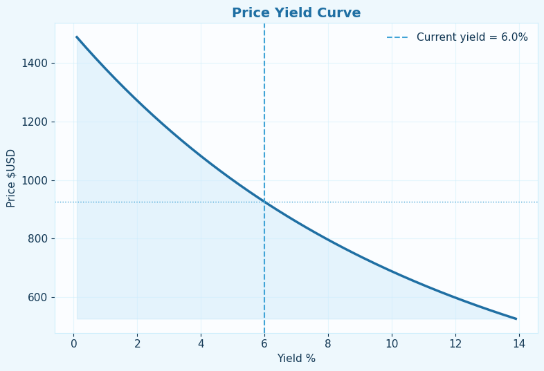

```python
#price yield curve
yield_range = np.arange(max(0.1, MARKET_YIELD-8), MARKET_YIELD+8, 0.1)
prices = [price_from_yield(flows, y, FREQ) for y in yield_range]

fig, ax = plt.subplots(figsize=(8, 5.5))
ax.plot(yield_range, prices, color=BLUE_DEEP, linewidth=2.5)
ax.fill_between(yield_range, prices, min(prices), color=BLUE_BRT, alpha=0.18)
ax.axvline(MARKET_YIELD, color=BLUE_MID, linestyle='--', linewidth=1.5, label=f'Current yield = {MARKET_YIELD}%')
ax.axhline(price, color=BLUE_MID, linestyle=':', linewidth=1)
ax.set_xlabel('Yield %')
ax.set_ylabel('Price $USD')
ax.set_title('Price Yield Curve', fontsize=14, fontweight='bold')
ax.legend(frameon=False)
ax.grid(alpha=0.5)
plt.tight_layout()
plt.show()
```

## 7. Duration & Convexity Approximation Check

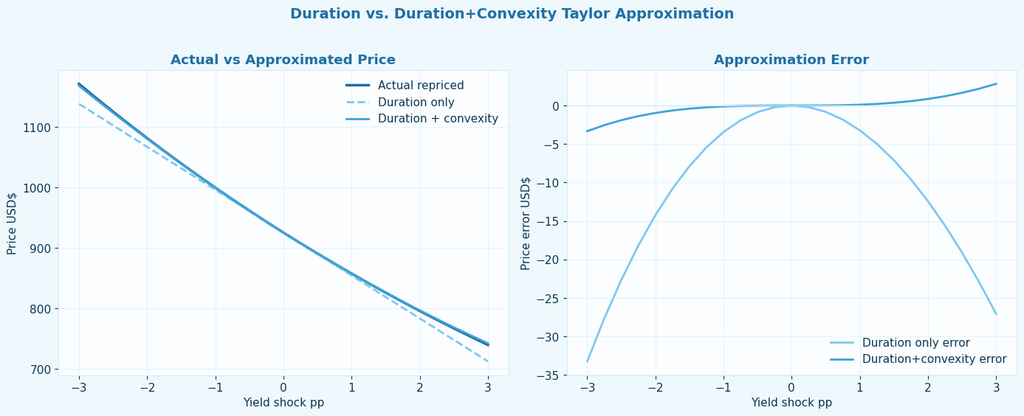

```python
#Duration & Convexity approximation check
shocks = np.arange(-3, 3.01, 0.25)  #percentage point yield shocks

actual = np.array([price_from_yield(flows, MARKET_YIELD+s, FREQ) for s in shocks])
dur_only = price - mod_d*price*(shocks/100)
dur_conv = price - mod_d*price*(shocks/100) + 0.5*conv*price*(shocks/100)**2

fig, axes = plt.subplots(1, 2, figsize=(14, 5.5))

axes[0].plot(shocks, actual, color=BLUE_DEEP, linewidth=2.5, label='Actual repriced')
axes[0].plot(shocks, dur_only, color=BLUE_BRT, linestyle='--', linewidth=2, label='Duration only')
axes[0].plot(shocks, dur_conv, color=BLUE_MID, linewidth=2, label='Duration + convexity')
axes[0].set_xlabel('Yield shock pp')
axes[0].set_ylabel('Price USD$')
axes[0].set_title('Actual vs Approximated Price', fontweight='bold')
axes[0].legend(frameon=False)
axes[0].grid(alpha=0.5)

err_dur = dur_only - actual
err_conv = dur_conv - actual
axes[1].plot(shocks, err_dur, color=BLUE_BRT, linewidth=2, label='Duration only error')
axes[1].plot(shocks, err_conv, color=BLUE_MID, linewidth=2, label='Duration+convexity error')
axes[1].axhline(0, color=BLUE_SOFT, linewidth=1)
axes[1].set_xlabel('Yield shock pp')
axes[1].set_ylabel('Price error USD$')
axes[1].set_title('Approximation Error', fontweight='bold')
axes[1].legend(frameon=False)
axes[1].grid(alpha=0.5)

plt.suptitle('Duration vs. Duration+Convexity Taylor Approximation', fontsize=14, fontweight='bold', color=BLUE_DEEP, y=1.02)
plt.tight_layout()
plt.show()
```

## 8. Summary

- **Duration** measures the first order (linear) sensitivity of price to yield changes: it's accurate for small yield moves but systematically *underestimates* price gains on yield drops and *overestimates* price losses on yield rises, because the true price yield relationship is convex, not linear.
- **Convexity** is the second order correction: adding it brings the estimated price curve much closer to the true repriced bond, especially for larger yield shocks (±2-3 percentage points).
- The **YTM solver** (Newton Raphson + bisection fallback) recovers the discount rate implied by any observed market price, which is the standard way bond yields are quoted from prices in practice.

Try changing `COUPON_RATE`, `YEARS`, `FREQ`, or `MARKET_YIELD` / `MARKET_PRICE` in the cells above and rerunning to see how the price, duration, and convexity shift for a different bond.